# Desafio I - Processos Pontuais

Estatística Espacial I

[figure not shown]

# 1 Objetivo

O estudo se baseia no conjunto de dados recolhidos por Andrew Bevan da University College London.

As informações contêm a localização de pessoas sentadas na grama do Gordon Square.

Os pesquisadores Igor Freitas e João Pedro Fernandes, pensando em realizar uma viagem a Londres em busca de aprimorar a língua inglesa, decidiram estudar locais com possíveis aglomerações a fim de achar um local adequado para encontrar um maior número de falantes nativos e assim, ter maior contato com o idioma inglês.

Além disso, um bom lugar para realizar piqueniques, sendo esses locais com conglomerados de pessoas.

# 2 Análises exploratórias

Os dados referentes à localização de pessoas sentadas na grama do Gordon Square em Londres, Inglaterra às 15h de uma tarde ensolarada.

Cada coordenada corresponde a uma única pessoa sendo que esta coordenada é dada em metros.

Como é possível observar na figura abaixo, há dois buracos no espaço observado, que apresenta a forma de um polígono irregular.

Aparentemente, próximo ao menor buraco, há uma certa aglomeração de pessoas, podendo indicar que é uma região propícia a confraternizações.

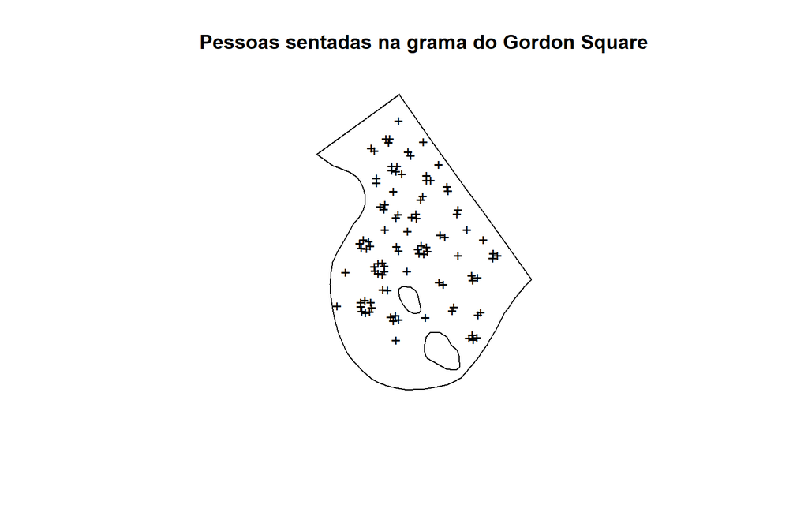

**Figura 1 - Localização de pessoas sentadas na grama do Gordon Square, Londres às 15h de um dia ensolarado**

# 3 Análises do padrão de pontos

## 3.1 Parte I

Através do Método dos Quadrantes, foi viável contabilizar o número de pessoas sentadas em cada quadrante em que a área do Gordon Square foi dividida.

Pela escolha feita do número de quadrantes, observa-se que acima e ao lado esquerdo do menor buraco parece haver uma maior concentração, o que corrobora com a análise inicial.

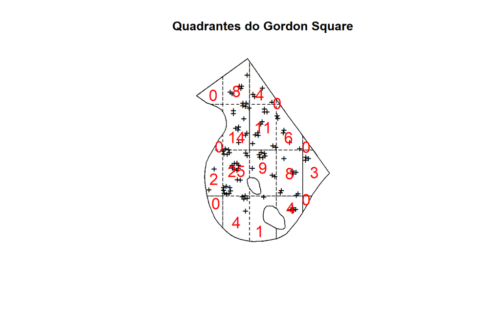

**Figura 2 - Dispersão de pessoas em cada quadrante**

## 3.2 Parte II

Calculou-se o Índice de Tamanho de Cluster (ICS), que se utiliza da média e da variância das contagens em cada quadrante, cujo valor nos dará um indicativo sobre o tipo de padrão de pontos.

A média encontrada foi $\bar{x}$ = 5.2105263 e a variância $s^2$ = 38.5872576.

Assim, ICS=6.4056353. Como o ICS é maior que 0, é indicada a aglomeração de pessoas.

Realizando o Teste de Quadrantes para Aleatoriedade Espacial Completa (CSR), foi confrontada a hipótese de que o processo pontual segue o modelo CSR versus a hipótese de que não segue.

Para a avaliação do teste, foi obtido o valor da estatística de teste $X^2$ e este valor foi comparado ao valor do quantil da distribuição Qui-Quadrado com 95% de confiança e 18 graus de liberdade.

Como $X^2$= 53.836 > $\chi_{0.95,18}$= 28.8693, rejeita-se a hipótese nula, ou seja, as evidências são de que não há aleatoriedade.

## 3.3 Parte III

Já que não existem evidências de aleatoriedade, podemos estimar as intensidades do número de eventos por área.

Primeiramente, foram estimadas as intensidades via Método dos Quadrantes, de forma que os resultados são possíveis de se verificar na Figura 3 abaixo.

Com a determinada quantidade de quadrantes escolhida, é perceptível que as faixas com maiores aglomerações de pessoas são aquelas à esquerda e logo acima do menor buraco.

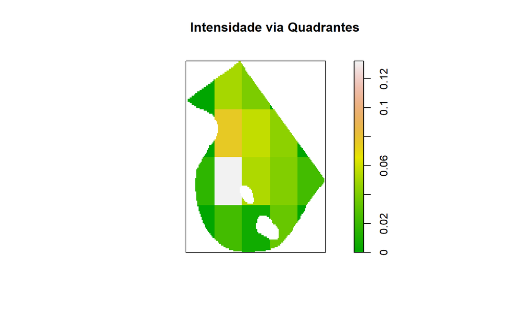

**Figura 3- Intensidade estimada via Quadrantes**

## 3.4 Parte IV

Analisando as intensidades estimadas via Kernel, pode-se chegar às mesmas conclusões das que foram observadas para o Método dos Quadrantes.

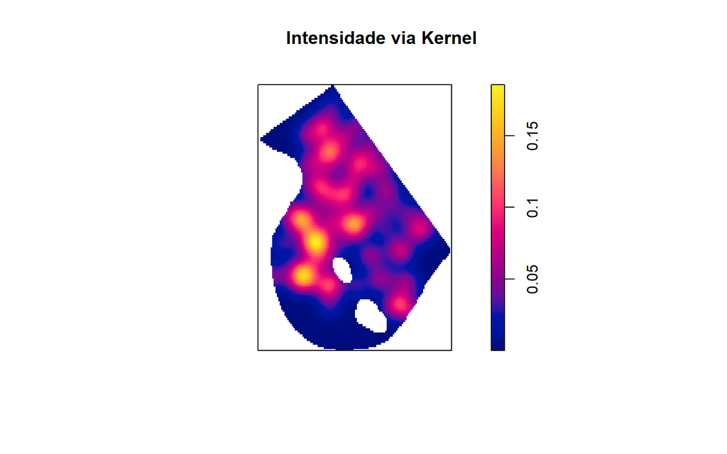

**Figura 4- Intensidade estimada via Kernel**

# 4 Conclusões

Neste trabalho, após traçar um objetivo inicial, foram feitas análises exploratórias e de padrões pontuais por meio de gráficos de dispersão e testes de quadrantes de CSR, respectivamente.

Com isso, foi possibilitado estimar intensidades via métodos de Quadrantes e de Kernel, a fim de auxiliar na tomada de decisões.

Por fim, é possível concluir que, pelo interesse dos pesquisadores, o melhor local para frequentarem seria aquele nas proximidades do menor buraco, destacando os lados norte e oeste, já que, pelas análises, esses são os que apresentam maior número de pessoas aglomeradas.